# **Title & Purpose**

"Terrain and Aid Station Report Generator for Ultra-Marathons"

This project semi-automates the creation of a detailed, print-ready PDF that breaks down trail segments between aid stations — helping athletes, coaches, and race directors better understand terrain and elevation challenges across the course.

## **Problem Statement:**

Ultra-marathons often take place in remote, mountainous regions where detailed topographic breakdowns are limited or non-existent.

To make informed pacing, nutrition, and gear decisions, runners and support teams need:

- Distance between aid stations
- Elevation gain/loss
- Slope grades
- Visual terrain profiles

This project fills that gap by converting GPX trail data into a comprehensive race-day planning tool.

## **Projects Motivation:**

As a former collegetiate athlete with a passion for creating high performance systems, I understand that success in any pursuit starts wth a thorough investigation into the challenge environment. Recently, I took up running as a way to challenge myself mentally and physically. What began as short runs ecalated quickly into a mission to race one of the most diffiult ultra marathons in the world: **The Leadville 50**. With under 9 months of running experience by race day, I will embark on a 50-mile, high altitude race that spans elevations from 9,900 to over 12,000 feet with almost 8000 feet of total ascent and decent. It’s an out-and-back course in the Colorado Rocky Mountain range with a strict 14-hour cutoff —a true test of pacing, endurance, and mental grit.

As a data scientist and software engineer, I approach this challenge with the same mindset I use in my work: process-driven, data-informed, and strategically prepared. I know that what I lack in experience, I can offset with structured preparation. That’s what led me to build this project.

### Leadville 50 Ultra Marathon:

- Event Website: https://www.leadvilleraceseries.com/run/silverrush50run/

### Race History:

- The Leadville Race Series boasts a rich legacy spanning over 40 years, but the roots of this story extend beyond just the last several decades. The town of Leadville holds a significant place in history, drawing visitors for centuries due to its distinctive character and unique historical events. With a past that encompasses both periods of prosperity and decline, the narrative of Leadville’s history is a compelling and captivating journey that merits sharing for generations to come. (Leadville Race Series, n.d., para. 1)

  The town of Leadville, Colorado, was founded in 1877 during the Colorado Silver Boom, which saw a massive influx of prospectors seeking to strike it rich in the mines that dotted the area. The town was named after the lead deposits that were discovered in the area, but it was the discovery of silver in 1878 that truly put Leadville on the map. (Leadville Race Series, n.d., para. 2)

  At its peak, the town boasted a population of more than 30,000 and was one of the wealthiest cities in the United States.The mining industry played a central role in Leadville’s early development, and the town was home to some of the richest silver mines in the world. The two largest mines, the Matchless Mine and the Little Jonny Mine, produced millions of dollars worth of silver each year, and their owners became some of the wealthiest people in the world. However, the boom times were not to last. (Leadville Race Series, n.d., para. 3)

  By the early 20th century, Leadville was in decline. The closure of the Climax Mine in the 1980s was a particularly devastating blow, leaving the town struggling to find a new identity and source of income. The town’s unemployment rate skyrocketed to the highest in the country and all of the challenges associated began to take its toll on the community. With nearly the entire town out of work, things were grim in the once-booming town of Leadville. The town struggled to find an identity and source of income for its residents. (Leadville Race Series, n.d., para. 4)

  Ken Chlouber, a local miner and businessman who was determined to put Leadville back on the map had an idea. He thought that tourism would be the key to Leadville’s revival, and he knew that visitors needed to stay overnight to have an economic impact. In 1983, Chlouber partnered with Merilee Maupin, and founded the Leadville Trail 100 Run, a grueling 100-mile ultramarathon that would take runners through the rugged mountain terrain surrounding the town. If they were going to run 100 miles, they sure would stay overnight! The race was an immediate success, attracting ultrarunners from around the world and bringing much-needed attention to Leadville. (Leadville Race Series, n.d., para. 5)

  Encouraged by the success of the Leadville Trail 100 Run, the duo went on to found the Leadville Race Series, which now includes a variety of races throughout the year, including the Silver Rush 50, the Leadville Trail Marathon & Heavy Half and the Leadville Stage Race. The Leadville Race Series has become one of the most popular and prestigious endurance race series in the world, attracting thousands of athletes and spectators to Leadville each year. (Leadville Race Series, n.d., para. 5)

  Source: [Leadville Race Series - History](https://www.leadvilleraceseries.com/history/)

#### Data Source:

The race route was downloaded as an interactive GPX file from  
[PlotARoute - Leadville 50 Course](https://www.plotaroute.com/route/2294456?units=km)

## Projects Outcome

- Process a GPX file
- Clean the raw data
- Perform Exploratory Data Analysis (EDA)
- Engineer Relevant Features
- Generates a professional-grade PDF race report:
  - Segment-by-segment terrain analysis
  - Elevation and slope metrics
  - Color-coded maps and elevation profiles by grade
  - Section notes for race planning

## Environment Setup

This project was developed and run on a **MacBook Pro M1** using a **Miniconda virtual environment** in **Jupyter Notebook**.

### Python Environment (via Conda)

To recreate the environment locally:

1. **Create the environment** (Python 3.12.11):

   conda create -n gpx_project python=3.12.11
2. **Activate the environment:**

   conda activate gpx_project
3. Install the required packages:

   conda install -c conda-forge gpxpy geopy matplotlib seaborn numpy pandas fpdf

Note: If 'fpdf' fails via conda, install it via pip: 'pip install fpdf'

```python
# ------------------------------------------------------------------------------
# Environment Check – You can run this to verify all packages are available
# ------------------------------------------------------------------------------
required_packages = [
    "gpxpy", "pandas", "geopy", "matplotlib", "seaborn", "numpy", "fpdf"
]

missing = []

for pkg in required_packages:
    try:
        __import__(pkg)
    except ImportError:
        missing.append(pkg)

if missing:
    print("Missing packages:", missing)
    print("You can install them with pip or conda.")
else:
    print("All required packages are installed.")
```

```
All required packages are installed.
```

```python
# ---------------------------------------------------------------------------
# --------------------------- Projects Imports -------------------------------
# ---------------------------------------------------------------------------
import gpxpy
import pandas as pd

from geopy.distance import geodesic
import matplotlib.pyplot as plt
import seaborn as sns

from __future__ import annotations

import os
from datetime import datetime
from pathlib import Path
from typing import List, Tuple, Dict

import numpy as np
import pandas as pd
import matplotlib.pyplot as plt
from matplotlib.collections import LineCollection
from fpdf import FPDF

import warnings
warnings.filterwarnings('ignore')
```

## Data Processing

GPX files are XML-based formats used to store GPS route data. They consist of one or more tracks, which contain segments, and those segments are made up of individual track points.

Each point records:

- **Latitude**
- **Longitude**
- **Elevation**
- **Timestamp**

### 📁 GPX File Structure:

```
GPX File
└── Track(s)
    └── Segment(s)
        └── Point(s): latitude, longitude, elevation, timestamp
```

To begin, we will define a function:

1. Load the `.gpx` file
2. Parse its contents into a Python-readable structure
3. Extract relevant values (`latitude`, `longitude`, `elevation`, and a running `sequence_id`)
4. Save the raw track points to a CSV file for further processing

```python
def load_and_parse_gpx(file_path, file_dest):

    with open(file_path, 'r') as gpx_file:
        gpx = gpxpy.parse(gpx_file)

    points = []
    for track in gpx.tracks:
        for segment in track.segments:
            for point in segment.points:
                points.append({
                    'latitude': point.latitude,
                    'longitude': point.longitude,
                    'elevation_m': point.elevation
                })

    df = pd.DataFrame(points)
    df['sequence_id'] = range(1, len(df) + 1)

    df.to_csv(file_dest, index=False)
    print(f'Raw GPX points saved to: {file_dest}')

    return df
```

```python
file_path = '2024 Silver Rush 50 Run And Bike.gpx'
file_dest = "./raw_gpx_points.csv"

df = load_and_parse_gpx( file_path, file_dest )
df.head(5)
```

```
Raw GPX points saved to: ./raw_gpx_points.csv
```

|  | latitude | longitude | elevation_m | sequence_id |
| --- | --- | --- | --- | --- |
| 0 | 39.239034 | -106.304011 | 3031.0 | 1 |
| 1 | 39.237497 | -106.303958 | 3054.0 | 2 |
| 2 | 39.237490 | -106.303957 | 3054.0 | 3 |
| 3 | 39.237484 | -106.304070 | 3053.0 | 4 |
| 4 | 39.237221 | -106.304001 | 3056.0 | 5 |

Now that we have extracted relevant features from the gpx file, we can build a function to clean and process the raw data points and save the clean data to csv.

```python
def clean_raw_gpx_data(file_path, file_dest):

    df = pd.read_csv(file_path)

    print("STEP 1 --- Checking for null values in the raw GPX data. ---\n")
    null_rows = df.isnull().any(axis=1)
    num_null_rows = null_rows.sum()
    if (num_null_rows > 0 ):
        print(f'WARNING: Found: {num_null_rows} null values.\n')
        print('Dropping null values...\n')
        df = df.dropna()
    else:
        print('SUCCESS: Zero null values found.\n')


    print("STEP 2 --- Validating latitude and longitude ranges. -------\n")
    try:
        assert df['latitude'].between(-90, 90).all()
        assert df['longitude'].between(-180, 180).all()
        print('SUCCESS: All latitude and longitude values fit within the correct range.\n')
    except AssertionError:
        raise ValueError(
            "TERMINAL ERROR: Terminating program due to invalid GPS coordinates found:\n"
            "Latitude must be between -90 and 90.\n"
            "Longitude must be between -180 and 180.\n"
        )


    print("STEP 3 --- Checking for duplicates. ------------------------\n")
    duplicate_count = df.duplicated().sum()
    if (duplicate_count  > 0 ):
        print(f'WARNING: Found: {duplicate_count} duplicate rows.\n')
        print('Dropping duplicate rows...\n')
        df = df.drop_duplicates()
    else:
        print('SUCCESS: Zero duplicate rows found.\n')


    print("STEP 4 --- Checking for redundant GPS points. --------------\n")
    redundant_mask = (df['latitude'].diff() == 0) & (df['longitude'].diff() == 0)
    redundant_count = redundant_mask.sum()
    if redundant_count > 0:
        print(f"WARNING: Found {redundant_count} redundant GPS points with no movement.\n")
        print("Dropping redundant GPS points...\n")
        df = df[~redundant_mask].reset_index(drop=True)
    else:
        print("SUCCESS: Zero redundant GPS points detected.\n")

    df.to_csv(file_dest, index=False)
    print(f'Clean GPX points saved to: {file_dest}')

    return df
```

```python
raw_path = './raw_gpx_points.csv'
clean_dest = './cleaned_gpx_points.csv'

try:
    df = clean_raw_gpx_data(raw_path, clean_dest)
except ValueError as e:
    print(f"ERROR: {e}")

df.head(5)
```

```
STEP 1 --- Checking for null values in the raw GPX data. ---

SUCCESS: Zero null values found.

STEP 2 --- Validating latitude and longitude ranges. -------

SUCCESS: All latitude and longitude values fit within the correct range.

STEP 3 --- Checking for duplicates. ------------------------

SUCCESS: Zero duplicate rows found.

STEP 4 --- Checking for redundant GPS points. --------------

WARNING: Found 198 redundant GPS points with no movement.

Dropping redundant GPS points...

Clean GPX points saved to: ./cleaned_gpx_points.csv
```

|  | latitude | longitude | elevation_m | sequence_id |
| --- | --- | --- | --- | --- |
| 0 | 39.239034 | -106.304011 | 3031.0 | 1 |
| 1 | 39.237497 | -106.303958 | 3054.0 | 2 |
| 2 | 39.237490 | -106.303957 | 3054.0 | 3 |
| 3 | 39.237484 | -106.304070 | 3053.0 | 4 |
| 4 | 39.237221 | -106.304001 | 3056.0 | 5 |

During the cleaning process, we removed **198 irrelevant or invalid GPS points**.

To ensure the cleaning did not introduce errors or data loss, we will perform a quick sanity check by:

1. Reloading both the **original raw dataset** and the **cleaned dataset**
2. Comparing the total number of GPS points in each
3. Comparing the total distance in each
4. Comparing the total elevation gain and loss
5. Ploting some visuals as we go.

```python
raw_df = pd.read_csv('./raw_gpx_points.csv')
clean_df = pd.read_csv('./cleaned_gpx_points.csv')
```

```python
print("Raw points:", len(raw_df))
print("Cleaned points:", len(clean_df))
```

```
Raw points: 2144
Cleaned points: 1946
```

We can see the number of points in the clean dataset is less then the raw dataset as expected.

Let's build a function to make sure the total course distance has not been corrupted.

```python
def compute_total_distance(df):
    coords = list(zip(df['latitude'], df['longitude']))
    total = sum(geodesic(coords[i], coords[i+1]).meters for i in range(len(coords)-1))
    return total / 1000

print("Raw total distance (km):", compute_total_distance(raw_df))
print("Cleaned total distance (km):", compute_total_distance(clean_df))
```

[output not shown]

Fortunately, the total course distance did not change after removing the redundant gps data points.

Now we can build a function to confirm the elevation profile stayed intact.

```python
def compute_elevation_gain_loss(df):
    diffs = df['elevation_m'].diff().fillna(0)
    gain = diffs[diffs > 0].sum()
    loss = -diffs[diffs < 0].sum()
    return gain, loss

raw_gain, raw_loss = compute_elevation_gain_loss(raw_df)
clean_gain, clean_loss = compute_elevation_gain_loss(clean_df)

print(f"Raw Elevation Gain: {raw_gain:.2f} m, Loss: {raw_loss:.2f} m")
print(f"Cleaned Elevation Gain: {clean_gain:.2f} m, Loss: {clean_loss:.2f} m")
```

```
Raw Elevation Gain: 2397.00 m, Loss: 2398.00 m
Cleaned Elevation Gain: 2397.00 m, Loss: 2398.00 m
```

Since the elevation appears to be unchanged, we can likely conclude the cleaning and processing step removed redundant information without corrupting the dataset.

Even though we should always trust data over visuals (due to cognitive bias), lets go ahead and plot the data to see if we notice any anomolies.

We can visualize anomolies by:

1. Plotting a route comparson.
2. Plotting an elevation profile by step (data point).
3. Plotting an elevation profile by distnace

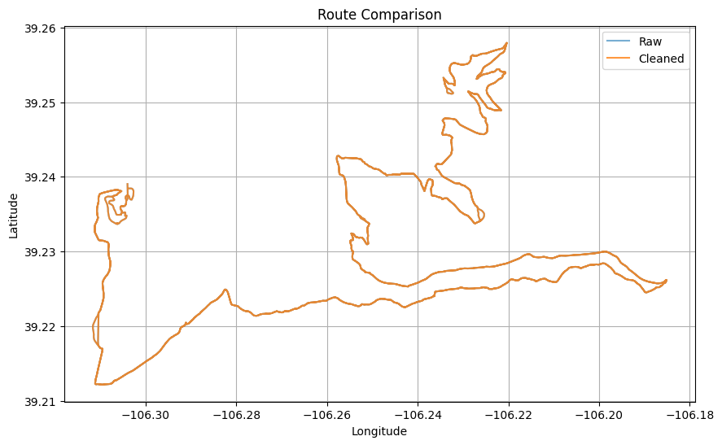

```python
plt.figure(figsize=(10, 6))
plt.plot(raw_df['longitude'], raw_df['latitude'], label='Raw', alpha=0.6)
plt.plot(clean_df['longitude'], clean_df['latitude'], label='Cleaned', alpha=0.8)
plt.title("Route Comparison")
plt.xlabel("Longitude")
plt.ylabel("Latitude")
plt.legend()
plt.grid(True)
plt.show()
```

As we can see in the plot above, both the raw data and clean data follow the exact same path without any clear anomolies.

Now if we plot an elevation profile based on gps points, the shape should look the same, but the clean data will be shifted to the left.

Additionally, if we plot an elevation profile by distance, we should see perfect alignment of the data.

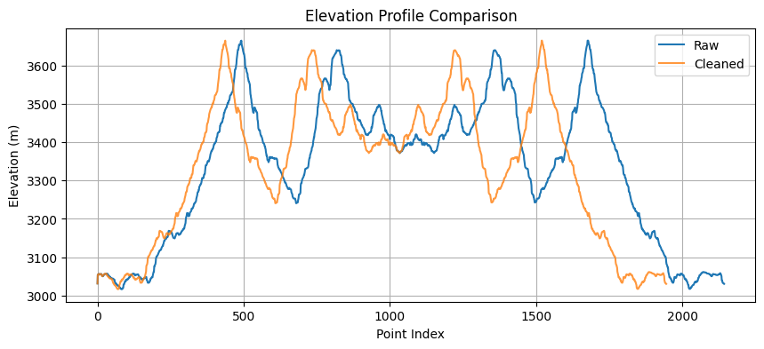

```python
plt.figure(figsize=(10, 4))
plt.plot(raw_df['elevation_m'], label='Raw')
plt.plot(clean_df['elevation_m'], label='Cleaned', alpha=0.8)
plt.title("Elevation Profile Comparison")
plt.xlabel("Point Index")
plt.ylabel("Elevation (m)")
plt.legend()
plt.grid(True)
plt.show()
```

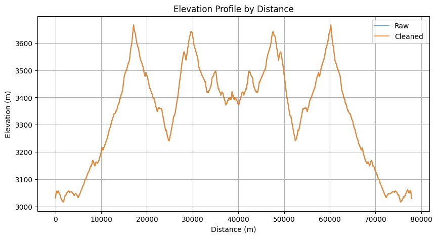

```python
def compute_distances(df):
    coords = list(zip(df['latitude'], df['longitude']))
    dists = [0.0]
    for i in range(1, len(coords)):
        d = geodesic(coords[i - 1], coords[i]).meters
        dists.append(dists[-1] + d)
    return dists

raw_df['distance_m'] = compute_distances(raw_df)
clean_df['distance_m'] = compute_distances(clean_df)

plt.figure(figsize=(10, 5))
plt.plot(raw_df['distance_m'], raw_df['elevation_m'], label='Raw', alpha=0.6)
plt.plot(clean_df['distance_m'], clean_df['elevation_m'], label='Cleaned', alpha=0.8)
plt.xlabel("Distance (m)")
plt.ylabel("Elevation (m)")
plt.title("Elevation Profile by Distance")
plt.legend()
plt.grid(True)
plt.show()
```

From the two previous plots, we can see everthing visually aligns with our expectations and no alomonies are detected. Once again we can conclude with confidence that cleaning the dataset did not corrupt any key features.

## Feature Engineering

Building a race strategy from a visual of elevation, latitude, and longitude, is simply not enough. To truly understand the course profle and develop a sound process for running the race, we must engineer new features from the data.

Since this event takes place in the US (where I live), We will convert all metric measurements to imperial measurements.

Additionally, we will engineer the following features:

`step-distance_ft` - The distance between each consecutive GPS point in the dataset, calculated via geodesic (earth surface) distance.

`elev_change_ft` - The change in elevation in feet, between each GPS point.

`cumulative_distance_ft` - The total accumulated distance in feet, from the start to the current GPS point.

`cumulative_miles` - The total accumulated distance in miles, from the start to the current GPS point.

`elev_up_ft`- The total elevation ascent between each step.

`elev_down_ft`- The total elevation loss between each step.

```python
def gpx_feature_engineering(file_path, file_dest):

    df = pd.read_csv(file_path)
    df['elevation_ft'] = df['elevation_m'] * 3.280839895
    df.drop(columns=['elevation_m'], inplace=True)

    distances_ft = [0.0]
    elev_changes_ft = [0.0]
    for i in range(1, len(df)):
        prev = (df.iloc[i - 1]['latitude'], df.iloc[i - 1]['longitude'])
        curr = (df.iloc[i]['latitude'], df.iloc[i]['longitude'])

        dist = geodesic(prev, curr).feet
        distances_ft.append(dist)

        elev_change_ft = df.iloc[i]['elevation_ft'] - df.iloc[i - 1]['elevation_ft']
        elev_changes_ft.append(elev_change_ft)

    df['step_distance_ft'] = distances_ft
    df['elev_change_ft'] = elev_changes_ft
    df['cumulative_distance_ft'] = df['step_distance_ft'].cumsum()
    df['cumulative_miles'] = df['cumulative_distance_ft'] / 5280
    df['elev_up_ft'] = df['elev_change_ft'].apply(lambda x: x if x > 0 else 0)
    df['elev_down_ft'] = df['elev_change_ft'].apply(lambda x: -x if x < 0 else 0)
    df.to_csv(file_dest, index=False)
    return df
```

```python
fp = './cleaned_gpx_points.csv'
fd = "./engineered_gpx_points.csv"
df = gpx_feature_engineering(fp, fd)
df.head(5)
```

|  | latitude | longitude | sequence_id | elevation_ft | step_distance_ft | elev_change_ft | cumulative_distance_ft | cumulative_miles | elev_up_ft | elev_down_ft |
| --- | --- | --- | --- | --- | --- | --- | --- | --- | --- | --- |
| 0 | 39.239034 | -106.304011 | 1 | 9944.225722 | 0.000000 | 0.000000 | 0.000000 | 0.000000 | 0.000000 | 0.00000 |
| 1 | 39.237497 | -106.303958 | 2 | 10019.685039 | 560.150325 | 75.459318 | 560.150325 | 0.106089 | 75.459318 | 0.00000 |
| 2 | 39.237490 | -106.303957 | 3 | 10019.685039 | 2.484748 | 0.000000 | 562.635073 | 0.106560 | 0.000000 | 0.00000 |
| 3 | 39.237484 | -106.304070 | 4 | 10016.404199 | 32.082319 | -3.280840 | 594.717392 | 0.112636 | 0.000000 | 3.28084 |
| 4 | 39.237221 | -106.304001 | 5 | 10026.246719 | 97.768305 | 9.842520 | 692.485696 | 0.131153 | 9.842520 | 0.00000 |

At this point we have processed and cleaned the dataset and engineered some additional features. Before designing the PDF builder, we will perform some exploratory data analysis (EDA) and get a better understanding of the data we are working with.

## Exploratory Data Analysis (EDA)

```python
df.shape
```

```
(1946, 10)
```

```python
df.info()
```

```
<class 'pandas.core.frame.DataFrame'>
RangeIndex: 1946 entries, 0 to 1945
Data columns (total 10 columns):
 #   Column                  Non-Null Count  Dtype
---  ------                  --------------  -----
 0   latitude                1946 non-null   float64
 1   longitude               1946 non-null   float64
 2   sequence_id             1946 non-null   int64
 3   elevation_ft            1946 non-null   float64
 4   step_distance_ft        1946 non-null   float64
 5   elev_change_ft          1946 non-null   float64
 6   cumulative_distance_ft  1946 non-null   float64
 7   cumulative_miles        1946 non-null   float64
 8   elev_up_ft              1946 non-null   float64
 9   elev_down_ft            1946 non-null   float64
dtypes: float64(9), int64(1)
memory usage: 152.2 KB
```

From the shape of the dataframe and a call to info(), we can see the dataset conatins zero null values and consists completely of numerical datatypes. Each feature is continuous except sequence_id, which should be classified as ordinal since it represents the position (order) of the gps point in the data.

```python
df.describe()
```

|  | latitude | longitude | sequence_id | elevation_ft | step_distance_ft | elev_change_ft | cumulative_distance_ft | cumulative_miles | elev_up_ft | elev_down_ft |
| --- | --- | --- | --- | --- | --- | --- | --- | --- | --- | --- |
| count | 1946.000000 | 1946.000000 | 1946.000000 | 1946.000000 | 1946.000000 | 1946.000000 | 1946.000000 | 1946.000000 | 1946.000000 | 1946.000000 |
| mean | 39.234397 | -106.248404 | 1079.547790 | 10940.446181 | 131.390045 | -0.001686 | 126352.656488 | 23.930427 | 4.041199 | 4.042885 |
| std | 0.011255 | 0.034678 | 615.829185 | 601.427059 | 114.232581 | 12.234007 | 73791.207009 | 13.975607 | 7.631049 | 7.664530 |
| min | 39.212167 | -106.311640 | 1.000000 | 9895.013123 | 0.000000 | -88.582677 | 0.000000 | 0.000000 | 0.000000 | 0.000000 |
| 25% | 39.225725 | -106.269942 | 545.250000 | 10387.139108 | 58.029364 | -6.561680 | 65626.842527 | 12.429326 | 0.000000 | 0.000000 |
| 50% | 39.232399 | -106.237818 | 1085.500000 | 11074.475066 | 103.740732 | 0.000000 | 126442.788259 | 23.947498 | 0.000000 | 0.000000 |
| 75% | 39.241407 | -106.225169 | 1613.750000 | 11407.480315 | 166.917735 | 6.561680 | 184921.519743 | 35.023015 | 6.561680 | 6.561680 |
| max | 39.257930 | -106.185149 | 2144.000000 | 12027.559055 | 1416.256705 | 75.459318 | 255685.027604 | 48.425195 | 75.459318 | 88.582677 |

From the descriptive statistics we can see there is a large range in mean and standard deviation for this data. Since this project will not utilize machine learning technique we can leave the data as is (no normalization is needed).

Lets continue with EDA and plot some histograms for the following features:

- `elevation_ft`
- `step_distance_ft`
- `elev_change_ft`
- `elev_up_ft`
- `elev_down_ft`

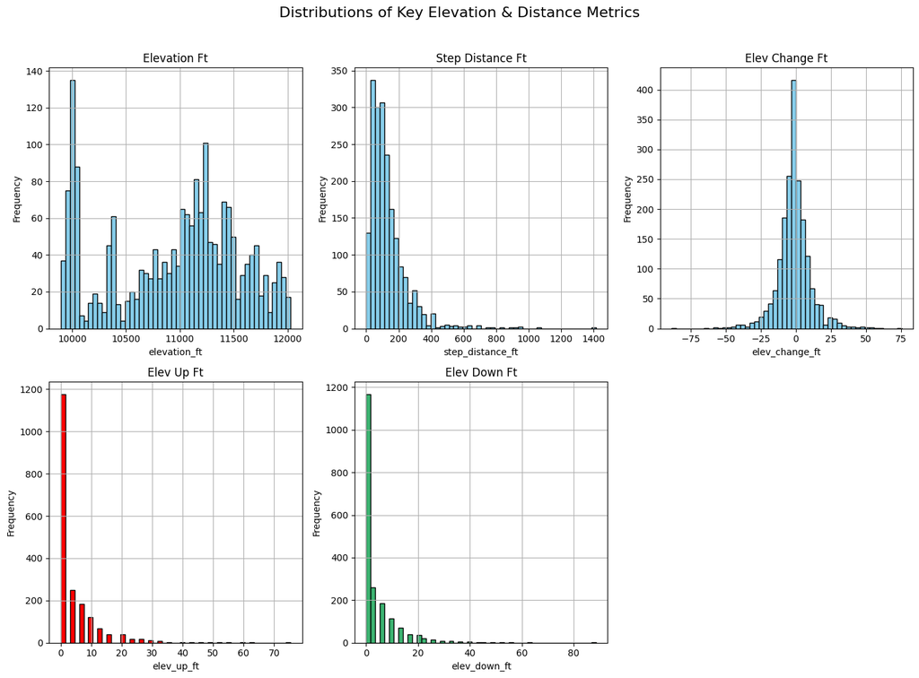

```python
import matplotlib.pyplot as plt

columns_to_plot = [
    "elevation_ft",
    "step_distance_ft",
    "elev_change_ft",
    "elev_up_ft",
    "elev_down_ft"
]

colors = ["skyblue", "skyblue", "skyblue", "red", "mediumseagreen"]

plt.figure(figsize=(14, 10))
for i, (col, color) in enumerate(zip(columns_to_plot, colors), 1):
    plt.subplot(2, 3, i)
    df[col].hist(bins=50, color=color, edgecolor='black')
    plt.title(col.replace("_", " ").title())
    plt.xlabel(col)
    plt.ylabel("Frequency")
    plt.grid(True)

plt.suptitle("Distributions of Key Elevation & Distance Metrics", fontsize=16, y=1.02)
plt.tight_layout()
plt.show()
```

## Histogram Analysis:

- **Elevation Ft:**
  - This plot reveals a multi-modal distribution with elevations ranging from just under 10,000 to 12,000 feet reflecting the high altitude of this race and a high level of difficulty. Since this is a mult-modal distribution it may indicate distinct elevation zones instead up a steady incline/decline.
- **Step Distance Ft:**
  - This distribution appears to be right-skewed. The majority of steps fit between 0 and 300 feet with some outliars at longer step distances like 1400 feet. These outliars could indicate a long straight section or flaws in collection of the gpx data.
- **Elevation Change Ft:**
  - This plot shows a relatively normal distribution for changes in elevation between each step. This can indicate a steady or balanced change in elevation beteeen steps, with minimal extreme inclines or declines between consecutive points.
- **Elevation Up/Down Ft:**
  - The plots representing elevation gain and loss are both right skewed and are highly similar. This is a result of accurate data on an out-and-back style course. Most of the gain or loss expected sits between 0 and 10 feet. With that said the long right tail indicates there will be steep downhill sections and steep uphill sections.
  - One potential cause of the outliars in these plots is the outliars in the step distances. Longer step distances will likely have larger amounts of ascent or descent recorded.

Now that we have processed and cleaned the data, engineered some basic features, and performed some exploratory data analysis we can continue with the building blocks of a PDF overview that includes statistical information for every tenth of a mile mile, color coded segments according to their slope percentage, and charts to visually enhance an individuals understanding of the terrain. Additionally, the overview will be split into segments based on aid stations, and a notes section will be added to each of these segments.

## Helper Functions

Lets start by building some helper functions.

### Micro-Segment Generation Function

This function takes the full course DataFrame and breaks it into ~0.10-mile segments based on cumulative distance.

Each segment includes:

- Elevation gain/loss
- Start/end lat/lon
- Net elevation change
- Slope percentage

```python
import pandas as pd

def generate_micro_segments(df, segment_length_ft):

    segments = []

    current = {
        "start_seq": df.loc[0, "sequence_id"],
        "start_mile": df.loc[0, "cumulative_miles"],
        "start_elev": df.loc[0, "elevation_ft"],
        "start_dist": df.loc[0, "cumulative_distance_ft"],
        "elev_up": 0.0,
        "elev_down": 0.0,
        "start_lat": df.loc[0, "latitude"],
        "start_lon": df.loc[0, "longitude"],
    }

    for i in range(1, len(df)):
        current["elev_up"] += df.loc[i, "elev_up_ft"]
        current["elev_down"] += df.loc[i, "elev_down_ft"]
        dist_from_start = df.loc[i, "cumulative_distance_ft"] - current["start_dist"]

        if dist_from_start >= segment_length_ft:
            end_elev = df.loc[i, "elevation_ft"]
            end_mile = df.loc[i, "cumulative_miles"]
            slope_pct = (
                (end_elev - current["start_elev"]) / dist_from_start * 100
                if dist_from_start else 0
            )
            segments.append(
                {
                    "segment_label": f"{current['start_mile']:.2f}-{end_mile:.2f}",
                    "segment_distance_ft": dist_from_start,
                    "total_elev_up_ft": current["elev_up"],
                    "total_elev_down_ft": current["elev_down"],
                    "start_elev_ft": current["start_elev"],
                    "end_elev_ft": end_elev,
                    "net_elev_change_ft": end_elev - current["start_elev"],
                    "slope_percent": slope_pct,
                    "start_lat": current["start_lat"],
                    "start_lon": current["start_lon"],
                    "end_lat": df.loc[i, "latitude"],
                    "end_lon": df.loc[i, "longitude"],
                    "start_mile": current["start_mile"],
                }
            )
            # Reset reference point
            current = {
                "start_seq": df.loc[i, "sequence_id"],
                "start_mile": df.loc[i, "cumulative_miles"],
                "start_elev": df.loc[i, "elevation_ft"],
                "start_dist": df.loc[i, "cumulative_distance_ft"],
                "elev_up": 0.0,
                "elev_down": 0.0,
                "start_lat": df.loc[i, "latitude"],
                "start_lon": df.loc[i, "longitude"],
            }

    segment_df = pd.DataFrame(segments)
    print(f"    -> Generated {len(segment_df)} micro-segments.")
    return segment_df
```

### Slope Color Function

Given a slope percentage, this function returns a color-coded RGB value based on custom-defined slope thresholds.

These colors are used to visually highlight steep climbs, descents, or flat areas on maps and elevation profiles.

```python
def slope_color(s, slope_ranges, color_codes ):
    for (min_slope, max_slope), color in zip(slope_ranges, color_codes):
        if min_slope <= s <= max_slope:
            return color
    return (0, 0, 0)
```

### Add Image Function

A utility to scale and center a given image inside a landscape A4 page with defined margins. Used to insert elevation charts and maps.

```python
from pathlib import Path
from fpdf import FPDF
from PIL import Image

def add_image(
    pdf: FPDF,
    img_path,
    page_margin_mm: int = 10,
    default_dpi: int = 150
):
    with Image.open(img_path) as im:
        img_px_w, img_px_h = im.size
        dpi_x, dpi_y = im.info.get("dpi", (default_dpi, default_dpi))

    img_mm_w = img_px_w / dpi_x * 25.4
    img_mm_h = img_px_h / dpi_y * 25.4

    max_mm_w = pdf.w - 2 * page_margin_mm
    max_mm_h = pdf.h - 2 * page_margin_mm

    scale = min(max_mm_w / img_mm_w, max_mm_h / img_mm_h)
    draw_w = img_mm_w * scale
    draw_h = img_mm_h * scale

    x_pos = (pdf.w - draw_w) / 2
    y_pos = (pdf.h - draw_h) / 2

    pdf.image(str(img_path), x=x_pos, y=y_pos, w=draw_w, h=draw_h)
```

### Safe Text Encoding Function

Ensures all strings are safe for use with the `FPDF` library, which only supports Latin-1 encoding.

```python
def safe_text(text):
    if text is None:
        return ""
    return str(text).encode("latin-1", "replace").decode("latin-1")
```

### Add Metrics Table Function

This function creates a table of segment stats for each aid section. Cells are color-coded by slope to quickly spot terrain difficulty.

```python
def add_metrics_table(
    pdf,
    seg_df,
    section_name: str,
    slope_color_fn,
    font_family: str = "Arial",
    page_margin_mm: int = 10
):
    pdf.add_page()
    pdf.set_font(font_family, "B", 14)
    pdf.cell(0, 10, safe_text(f"Section: {section_name}"), ln=True, align="C")
    pdf.ln(2)

    headers = [
        "Segment (mi)", "Elev + (ft)", "Elev - (ft)",
        "Start (ft)", "End (ft)", "Net change (ft)", "Slope %"
    ]
    col_width = (pdf.w - 2 * page_margin_mm) / len(headers)

    pdf.set_font(font_family, "B", 8)
    for h in headers:
        pdf.cell(col_width, 6, safe_text(h), border=1, align="C")
    pdf.ln()

    pdf.set_font(font_family, size=7)
    for _, row in seg_df.iterrows():
        r, g, b = slope_color_fn(row["slope_percent"])
        pdf.set_fill_color(r, g, b)
        cells = [
            row["segment_label"],
            f"{row['total_elev_up_ft']:.0f}",
            f"{row['total_elev_down_ft']:.0f}",
            f"{row['start_elev_ft']:.0f}",
            f"{row['end_elev_ft']:.0f}",
            f"{row['net_elev_change_ft']:.0f}",
            f"{row['slope_percent']:.1f}",
        ]
        for cell in cells:
            pdf.cell(col_width, 6, safe_text(cell), border=1, fill=True, align="C")
        pdf.ln()
```

### Add Elevation Plot Function

Plots average elevation over segment midpoints to visualize the terrain profile of each aid section.

```python
import matplotlib.pyplot as plt
import numpy as np
from pathlib import Path

def add_elevation_profile(
    pdf,
    seg_df,
    label: str,
    slope_color_fn,
    output_dir: Path,
    add_centered_image_fn,
    dpi: int = 150,
    title: str = "Elevation Profile"
):
    if len(seg_df) < 2:
        return

    fig, ax = plt.subplots(figsize=(12, 6))
    mids = seg_df["segment_label"].str.split("-").apply(
        lambda x: (float(x[0]) + float(x[1])) / 2
    )
    avg_elev = (seg_df["start_elev_ft"] + seg_df["end_elev_ft"]) / 2

    for i in range(len(seg_df) - 1):
        color = np.array(slope_color_fn(seg_df.iloc[i]["slope_percent"])) / 255
        ax.plot(
            mids.iloc[i : i + 2],
            avg_elev.iloc[i : i + 2],
            linewidth=3,
            color=color,
        )

    ax.set_title(title)
    ax.set_xlabel("Miles")
    ax.set_ylabel("Elevation (ft)")
    ax.grid(True)

    ax.scatter(mids.iloc[0], avg_elev.iloc[0], s=60, c="black", marker="o", zorder=5)
    ax.scatter(mids.iloc[-1], avg_elev.iloc[-1], s=60, c="black", marker="X", zorder=5)

    plt.tight_layout()
    elev_img = output_dir / f"{label}_elev.png"
    fig.savefig(elev_img, dpi=dpi)
    plt.close(fig)

    pdf.add_page()
    add_centered_image_fn(pdf, elev_img)
```

### Add Notes Page Function

Adds a lined page with optional notes for each aid section — designed for printing, coaching notes, or pacing strategies.

```python
def add_notes_page(
    pdf,
    section_name: str,
    label: str,
    section_notes: dict,
    font_family: str = "Arial",
    note_line_height: int = 8,
    extra_lines: int = 14
):

    pdf.add_page()
    pdf.set_font(font_family, "B", 12)
    pdf.cell(0, note_line_height, safe_text(f"Notes: {section_name}"), ln=True, align="C")
    pdf.ln(6)

    pdf.set_font(font_family, size=11)
    notes_text = section_notes.get(label, "No pre-written notes for this section.")
    pdf.multi_cell(0, note_line_height, safe_text(notes_text))
    pdf.ln(6)

    for _ in range(extra_lines):
        pdf.cell(0, note_line_height, "", ln=True, border="B")
```

### Add Overhead Map Plot Function

Generates a 2D map view of each aid section, colorized by slope, and inserts it into the PDF.

```python
import matplotlib.pyplot as plt
import numpy as np
from matplotlib.collections import LineCollection
from pathlib import Path

def add_map_plot(
    pdf,
    seg_df,
    label: str,
    slope_color_fn,
    output_dir: Path,
    add_image_fn,
    dpi: int = 150,
    title: str = "Overhead Trail Path"
):

    if len(seg_df) < 2:
        return

    lons = seg_df["start_lon"].to_numpy()
    lats = seg_df["start_lat"].to_numpy()

    fig, ax = plt.subplots(figsize=(12, 10))
    points = np.column_stack((lons, lats)).reshape(-1, 1, 2)
    segs = np.concatenate([points[:-1], points[1:]], axis=1)

    colors = [np.array(slope_color_fn(s)) / 255 for s in seg_df["slope_percent"]]
    lc = LineCollection(segs, colors=colors, linewidths=4)
    ax.add_collection(lc)
    ax.autoscale()
    ax.set_aspect("equal")

    ax.set_title(title)
    ax.set_xlabel("Longitude")
    ax.set_ylabel("Latitude")
    ax.grid(True)
    ax.scatter(lons[0],  lats[0],  s=60, c="black", marker="o", zorder=5, label="Start")
    ax.scatter(lons[-1], lats[-1], s=60, c="black", marker="X", zorder=5, label="End")
    ax.legend(loc="best")
    plt.tight_layout()

    map_img = output_dir / f"{label}_map.png"
    fig.savefig(map_img, dpi=dpi)
    plt.close(fig)

    pdf.add_page()
    add_image_fn(pdf, map_img)
```

### Section Renderer Function

Loops through each aid station section and adds:

- A metrics table
- A top-down map
- An elevation profile
- A notes page

Each section is sliced from the full course based on start and end mile markers.

```python
def render_aid_sections(
    pdf,
    aid_sections,
    segment_df,
    section_notes,
    slope_color_fn,
    output_dir,
    font_family,
    page_margin_mm,
    map_dpi,
    add_image_fn
):
    for start_mile, end_mile, label in aid_sections:
        section_name = label.replace("_", " ")
        seg_df = segment_df[
            (segment_df["start_mile"] >= start_mile)
            & (segment_df["start_mile"] < end_mile)
        ].reset_index(drop=True)

        add_metrics_table(pdf, seg_df, section_name, slope_color_fn, font_family, page_margin_mm)
        add_map_plot(pdf, seg_df, label, slope_color_fn, output_dir, add_image_fn, map_dpi)
        add_elevation_profile(pdf, seg_df, label, slope_color_fn, output_dir, add_image_fn, map_dpi)
        add_notes_page(pdf, section_name, label, section_notes, font_family)
```

## Main Report Generator: `generate_race_overview`

This is the core function. It:

- Loads and cleans the data
- Segments the trail
- Renders each aid section (map, table, chart, notes)
- Builds and saves a landscape A4 PDF

```python
from datetime import datetime
from pathlib import Path
import pandas as pd
from fpdf import FPDF

def generate_race_overview(
    file_path: Path,
    file_dest: Path,
    segment_length_ft: float,
    aid_sections: list,
    slope_color_fn,
    output_dir: Path,
    section_notes: dict = None,
    font_family: str = "Arial",
    page_margin_mm: int = 10,
    map_dpi: int = 150,
    report_title: str = "Leadville 50 - Terrain & Aid-Station Report"
):

    if section_notes is None:
        section_notes = {}

    # -------------------- Load CSV --------------------
    print("Loading terrain data…")
    if not file_path.exists():
        raise FileNotFoundError(f"Expected CSV not found at {file_path}")

    df = pd.read_csv(file_path).sort_values("sequence_id").reset_index(drop=True)

    # -------------------- Segment Trail --------------------
    seg_df = generate_micro_segments(df, segment_length_ft)

    # -------------------- Set Up PDF --------------------
    print("Building PDF report…")

    pdf = FPDF(orientation="L", unit="mm", format="A4")
    pdf.set_auto_page_break(auto=True, margin=page_margin_mm)
    pdf.set_margins(page_margin_mm, page_margin_mm, page_margin_mm)
    pdf.alias_nb_pages()

    # -------------------- Title Page --------------------
    pdf.add_page()
    pdf.set_font(font_family, "B", 28)
    pdf.cell(0, 20, safe_text(report_title), ln=True, align="C")

    pdf.set_font(font_family, size=12)
    pdf.ln(4)
    course_dist = df["cumulative_miles"].max()
    cum_up = seg_df["total_elev_up_ft"].sum()
    cum_down = seg_df["total_elev_down_ft"].sum()
    created = datetime.now().strftime("%B %d, %Y")

    summary_lines = [
        f"Total distance: {course_dist:.1f} miles",
        f"Total elevation gain: {cum_up:,.0f} ft",
        f"Total elevation loss: {cum_down:,.0f} ft",
        f"Aid sections: {len(aid_sections)}",
        f"Micro-segment target length: {segment_length_ft / 5280:.2f} miles (~{segment_length_ft:.0f} ft)",
        f"Report generated: {created}",
    ]
    for line in summary_lines:
        pdf.cell(0, 8, safe_text(line), ln=True, align="C")

    pdf.ln(10)
    pdf.set_font(font_family, "I", 12)
    pdf.multi_cell(0, 8, safe_text("General notes:"))
    for _ in range(10):
        pdf.cell(0, 8, "", ln=True, border="B")

    # -------------------- Aid Sections --------------------
    render_aid_sections(
        pdf=pdf,
        aid_sections=aid_sections,
        segment_df=seg_df,
        section_notes=section_notes,
        slope_color_fn=slope_color_fn,
        output_dir=output_dir,
        font_family=font_family,
        page_margin_mm=page_margin_mm,
        map_dpi=map_dpi,
        add_image_fn=add_image
    )

    # -------------------- Save PDF --------------------
    print(f"Writing output ➜ {file_dest}")
    pdf.output(str(file_dest))
    print("Done!")
```

## Report Configuration & Execution

This cell defines:

- File paths for input data and output PDF/images
- Aid station breakpoints and optional notes
- Slope ranges and color codes for terrain grading

Then it calls the main report generator:

- `generate_race_overview(...)`

```python
from pathlib import Path
from typing import List, Tuple, Dict

# --- Config ---
DATA_FILE: Path = Path("./engineered_gpx_points.csv")
OUTPUT_DIR: Path = Path("./seg_data")
OUTPUT_PDF: Path = Path("./Complete_Terrain_Profile.pdf")
OUTPUT_DIR.mkdir(parents=True, exist_ok=True)

GOAL_SEGMENT_LENGTH_FT: float = 528.0

aid_sections: List[Tuple[float, float, str]] = [
    (0.0, 7.7, "1_Start_to_Black_Cloud"),
    (7.7, 14.3, "2_Black_Cloud_to_Printer_Boy"),
    (14.3, 18.6, "3_Printer_Boy_to_Venir"),
    (18.6, 24.0, "4_Venir_to_Stumptown"),
    (24.0, 29.4, "5_Stumptown_to_Venir"),
    (29.4, 34.2, "6_Venir_to_Printer_Boy"),
    (34.2, 40.3, "7_Printer_Boy_to_Black_Cloud"),
    (40.3, 50.0, "8_Black_Cloud_to_Finish"),
]

section_notes: Dict[str, str] = {label: "" for _, _, label in aid_sections}

# --- Slope color function ---
slope_ranges = [(-float("inf"), -7), (-7, -3), (-3, 3.5), (3.5, 7), (7, float("inf"))]

color_codes = [
    (102, 205, 102), (180, 238, 180), (200, 230, 255),
    (255, 210, 210), (255, 140, 140)
]

def slope_color(s: float) -> tuple[int, int, int]:
    for (min_s, max_s), color in zip(slope_ranges, color_codes):
        if min_s <= s <= max_s:
            return color
    return (255, 255, 255)

# --- Run the report ---
generate_race_overview(
    file_path=DATA_FILE,
    file_dest=OUTPUT_PDF,
    segment_length_ft=GOAL_SEGMENT_LENGTH_FT,
    aid_sections=aid_sections,
    slope_color_fn=slope_color,
    output_dir=OUTPUT_DIR,
    section_notes=section_notes,
    report_title="Leadville 50 - Terrain Profile"
)
```

```
Loading terrain data…
    -> Generated 398 micro-segments.
Building PDF report…
Writing output ➜ Complete_Terrain_Profile.pdf
Done!
```

Lets take a look at the first segment of the pdf.

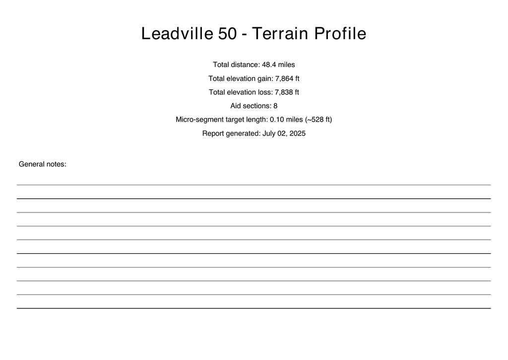

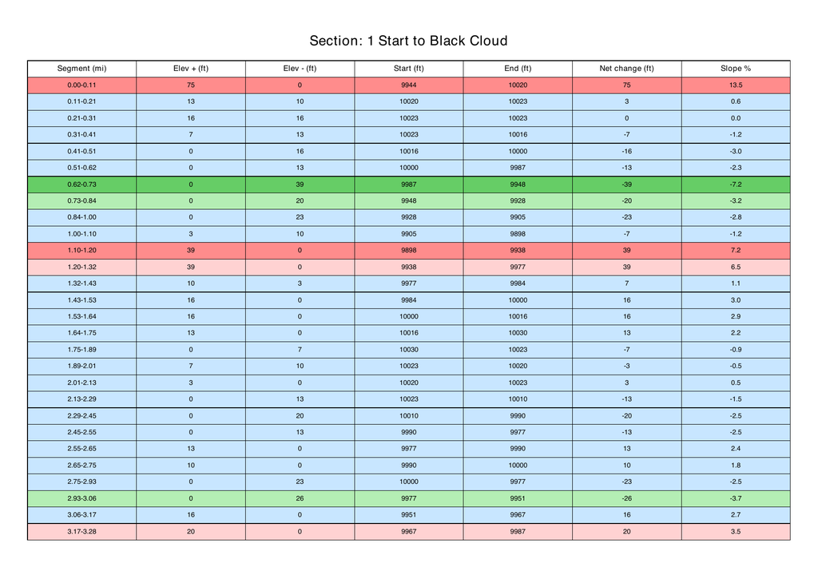

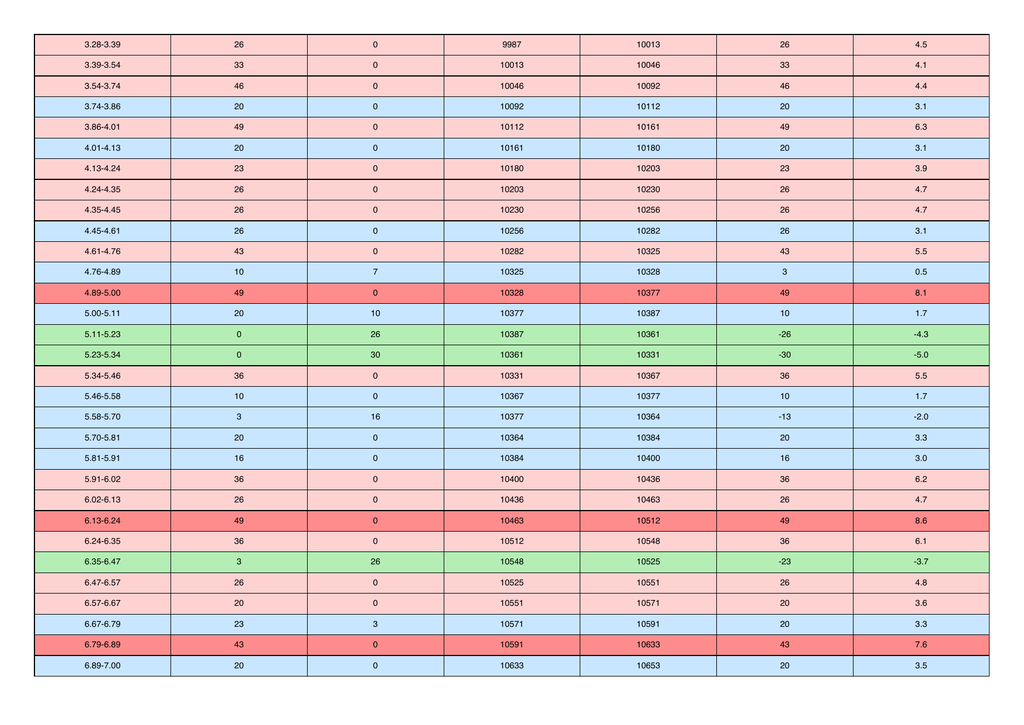

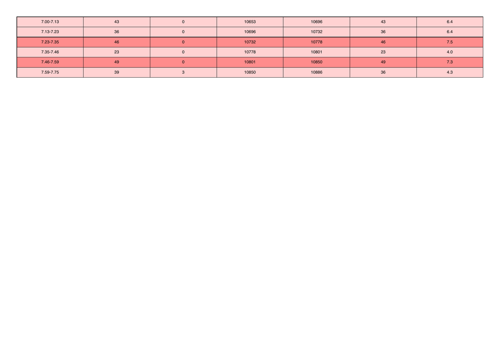

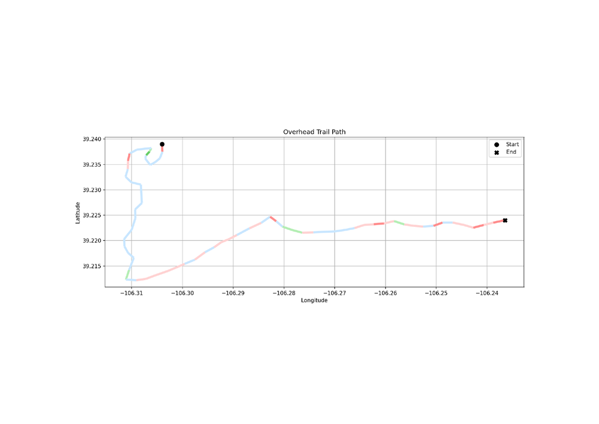

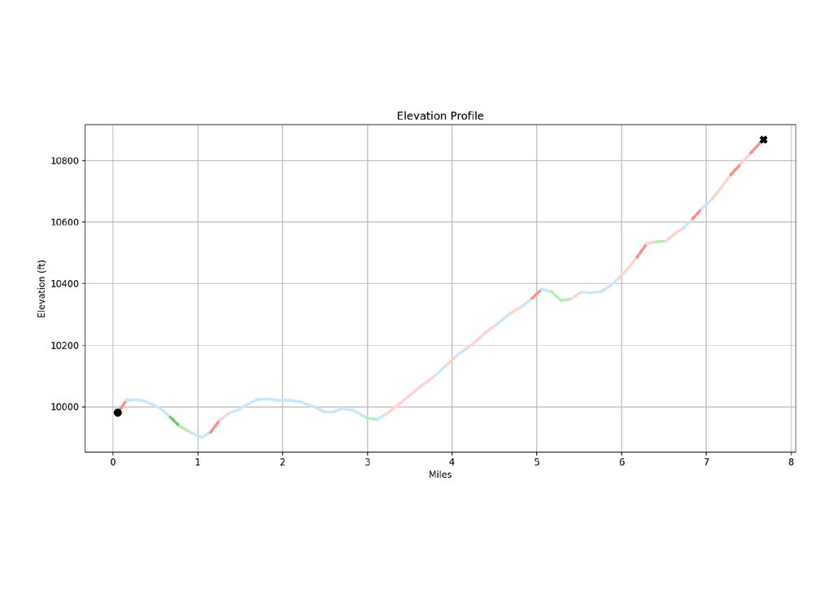

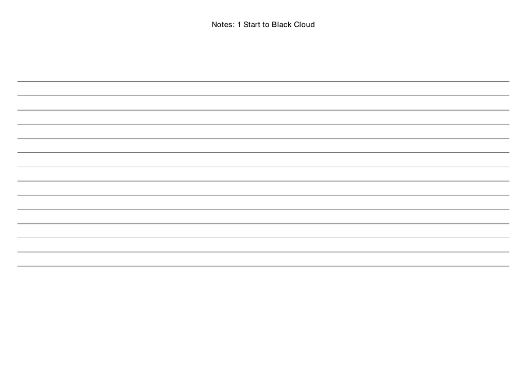

```python
from pdf2image import convert_from_path
from IPython.display import display
from PIL import Image

# Convert PDF to list of images (each page)
images = convert_from_path("./Complete_Terrain_Profile.pdf", dpi=150)

# Display the first 10 pages (or fewer if shorter)
for img in images[:7]:
    display(img)
```